# Laboratório 5 CP 3

# Introdução

A análise será feita sobre os mesmos dados da anterior, sendo esses os dados do Speed Dating (que descrevem 5000 encontros relâmpagos de 4 minutos envolvendo 310 jovens americanos. Onde após cada encontro, os participantes preenchiam fichas avaliando aqueles com quem se encontraram), no entanto o objetivo dela é correlacionar a ‘nova’ coluna dec (que diz se p1 gostaria de se encontrar novamente com p2) com os dados de como foi o encontro relâmpago.

Esse estudo deverá ser capaz de responder as seguintes perguntas:

1. Dentre os fatores que você acha que podem ter efeito no match (dec), quais fatores têm efeito significativo na chance de p1 decidir se encontrar novamente com p2? E como é esse efeito (positivo/negativo)?
2. Que fatores nos dados têm mais efeito na chance de um participante querer se encontrar novamente com outro?)

### Exportando e limpando os dados

```r
speed_dating <- read_csv("speed-dating2.csv")

speed_dating <- speed_dating %>%
  dplyr::select(dec, attr, fun, sinc, amb, like, shar,intel, fun, prob) %>%
  mutate(dec = as.factor(dec)) %>%
  na.omit()
```

# Explorando as Variáveis

As variáveis escolhidas foram as de avaliação do encontro:

1. attr : quão atraente p1 achou p2
2. sinc : quão sincero p1 achou p2
3. intel : quão inteligente p1 achou p2
4. fun : quão divertido p1 achou p2
5. amb : quão ambicioso p1 achou p2
6. shar : quanto p1 achou que compartilha interesses e hobbies com p2
7. like : no geral, quanto p1 gostou de p2?
8. prob : que probabiliade p1 acha que p2 tem de querer se encontrar novamente com p- (escala 1-10)

Elas foram filtradas dessa maneira pois são as mais relevantes para o estudo, dado que queremos saber o que no encontro relâmpago mais influencia a vontade de um participante querer encontrar o outro novamente. Sendo assim primeiro visualizaremos a distribuição de todas essas variáveis em relação a dec (em boxplots) para ter uma ideia do panorama geral dos dados.

Temos que se o boxplot de uma variável mostrar que quando dec é ‘no’ ela se concentra nas notas baixas e quando dec é ‘yes’ ela se concentra em notas altas é mais provável que haja uma correlação positiva entre a variável e a vontade de um participante querer encontrar outro novamente. Da mesma maneira se as notas baixas se concentrarem no ‘yes’ e as altas no ‘no’ há mais probabilidade de existir uma correlação também, porém negativa.

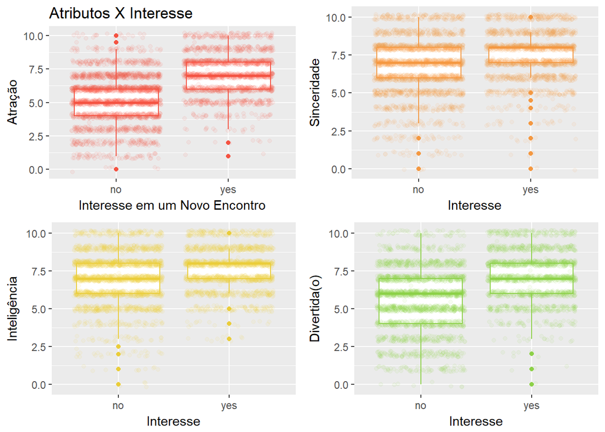

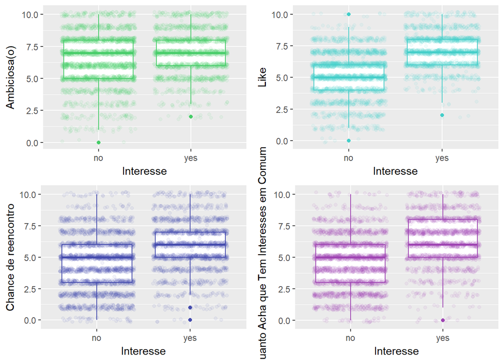

Dessa maneira podemos observar que quatro variáveis se destacam, a atração, o quanto a pessoa é divertida, o like e a chance de reencontro, todas com correlação aparentemente positiva. Iremos provar, ou refutar essa hipótese criando o modelo com regressão logística.

# Modelo

```r
model <- glm(dec ~ attr + sinc + intel + fun + shar + amb + like + prob,
              data = speed_dating,
              family = "binomial")

tidy(model, conf.int = TRUE, exponentiate = TRUE)
```

```
##          term    estimate  std.error  statistic       p.value   conf.low
## 1 (Intercept) 0.002482209 0.27095423 -22.138818 1.336958e-108 0.00144839
## 2        attr 1.541299433 0.03109243  13.914186  5.194789e-44 1.45081475
## 3        sinc 0.790841097 0.03424587  -6.852162  7.274214e-12 0.73925318
## 4       intel 0.954120764 0.04135026  -1.135785  2.560464e-01 0.87968684
## 5         fun 1.130876259 0.03327366   3.696401  2.186778e-04 1.05963753
## 6        shar 1.168809292 0.02679355   5.821757  5.823207e-09 1.10917134
## 7         amb 0.808244047 0.03234939  -6.580996  4.673072e-11 0.75834484
## 8        like 1.859981029 0.04362670  14.224460  6.460063e-46 1.70902601
## 9        prob 1.183148853 0.02285420   7.358796  1.855767e-13 1.13146067
##   conf.high
## 1 0.0041904
## 2 1.6389389
## 3 0.8455022
## 4 1.0345322
## 5 1.2073164
## 6 1.2320510
## 7 0.8609052
## 8 2.0278971
## 9 1.2375393
```

Dessa maneira podemos concluir que a atração, o quanto a pessoa é divertida, a quantidade de interesses que a pessoa crê que tem em comum com a outra, o quanto ela gostou da outra e a probabilidade de que o participante acha que aquela quer vê-la novamente são as variáveis independentes que tem influência positiva no modelo.

De maneira análoga, temos que as variáveis com o valor estimate menor do que 1, isto é: Ambição, sinceridade e inteligência, possuem correlação negativa com dec (o interesse em ter um novo encontro).

### Pseudo R²

A regressão logística não possui um valor R² convencional que mostra o quanto o modelo explica o comportamento da variável, porém com o uso da função pR2, iremos mostrar os valores das medidas dos pseudo R² existentes:

```r
pR2(model)
```

```
##           llh       llhNull            G2      McFadden          r2ML
## -1888.4241414 -2793.2364426  1809.6246024     0.3239297     0.3567773
##          r2CU
##     0.4795981
```

Assim temos que:

De acordo com o pseudo R² de McFadden o modelo explica 32% do comportamento da variável. Utilizando o Maximum Likehood teriamos que o modelo explica 35,7% do comportamento e de acordo com o pseudo R² de Cragg e Uhler o modelo explica aproximadamente 48% do comportamento da variável.

## Respondendo a Primeira Pergunta

Usaremos o stargazer para mostrar de maneira mais legível as correlações entre as variáveis independentes e a dependente.

```r
stargazer(model, type="text")
```

```
##
## =============================================
##                       Dependent variable:
##                   ---------------------------
##                               dec
## ---------------------------------------------
## attr                       0.433***
##                             (0.031)
##
## sinc                       -0.235***
##                             (0.034)
##
## intel                       -0.047
##                             (0.041)
##
## fun                        0.123***
##                             (0.033)
##
## shar                       0.156***
##                             (0.027)
##
## amb                        -0.213***
##                             (0.032)
##
## like                       0.621***
##                             (0.044)
##
## prob                       0.168***
##                             (0.023)
##
## Constant                   -5.999***
##                             (0.271)
##
## ---------------------------------------------
## Observations                 4,101
## Log Likelihood            -1,888.424
## Akaike Inf. Crit.          3,794.848
## =============================================
## Note:             *p<0.1; **p<0.05; ***p<0.01
```

Dessa forma temos que, em ordem de significância, os fatores que tem efeito positivo na chance de p1 decidir se encontrar novamente com p2 são:

1. O quanto p1 gostou de p2 (like)
2. O quanto p1 achou p2 atraente (attr)
3. O quanto p1 acha que p2 vai querer um segundo encontro (prob)
4. O quanto p1 acha que tem interesses em comum com p2 (shar)
5. O quanto p1 achou p2 divertido (fun)

Agora, em ordem de significância, os fatores que tem efeito negativo na chance de p1 decidir se encontrar novamente com p2:

1. O quanto p1 achou p2 sincero (sinc)
2. O quanto p1 achou p2 ambicioso (amb)
3. O quanto p1 achou p2 inteligente (intel)

Porém temos que o quanto p1 achou p2 inteligente chega a ser quase irrelevante nesse modelo, é uma influência bastante fraca.

## Respondendo a Segunda Pergunta

“Que fatores nos dados têm mais efeito na chance de um participante querer se encontrar novamente com outro?”

Esses fatores seriam o like e o attr, isto é, o quanto p1 gostou de p2 e o quanto p1 achou p2 atrante, respectivamente. Ambos os fatores tem correlação bem mais alta do que os outros escolhidos para esse estudo.

Apesar de não influenciarem tanto quanto os citados acima iremos citar a sinceridade e ambição como relevantes também, pois suas influências negativas são maiores do a de todas as outras variáveis (menos like e attr) sendo a influência destas positiva ou não.

## Previsões do Modelo

Abaixo iremos analisar se o modelo tem muitos acertos em relação à suas previsões:

```r
previsoes = model %>%
  augment(type.predict = "response") %>%
  mutate(modelo = .fitted > .5,
         dados = dec == "yes")

xtabs(~ modelo + dados, data = previsoes)
```

```
##        dados
## modelo  FALSE TRUE
##   FALSE  1920  500
##   TRUE    448 1233
```

### Visualização

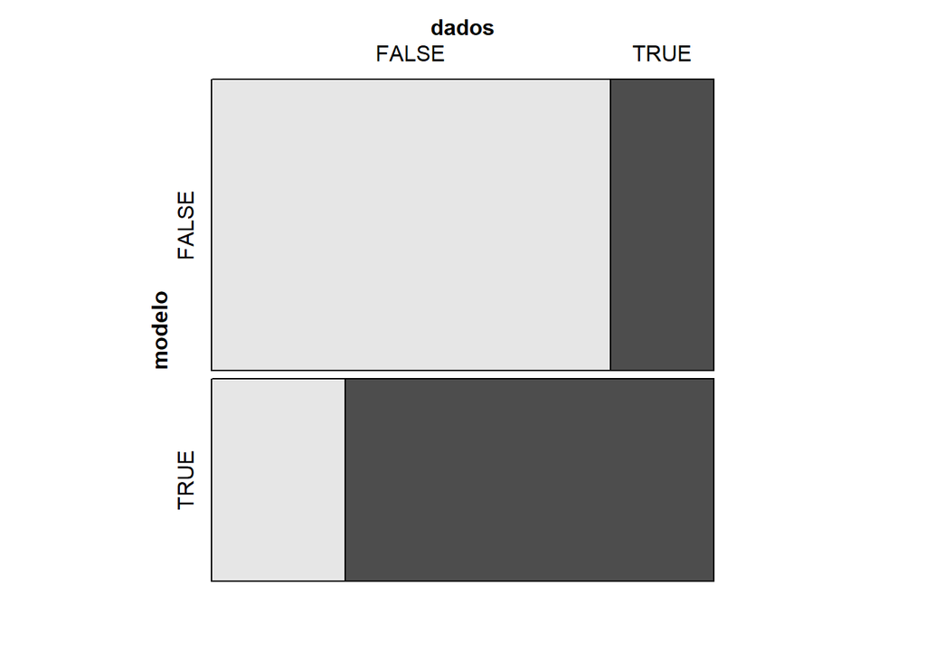

```r
mosaic(dados ~ modelo, data = previsoes,
       shade = TRUE)
```

A parte cinza clara na variável FALSE (em modelo) representa os acertos, na TRUE a parte cinza escura é a que representa os acertos do modelo.